# SB_MASLD_STATISTICS

Guilherme Ferreira

2025-04-26

```r
rm(list = ls())

# Code to download the required packages

cat("R Downloaded packages package:\n")
```

```
## R Downloaded packages package:
```

```r
# Verificar e instalar pacotes necessários
required_packages <- c("survey", "tidyverse", "skimr", "lmtest", "nortest", "gt", "gtsummary", "broom", "here","rio")

for (pkg in required_packages) {
  if (!requireNamespace(pkg, quietly = TRUE)) {
    install.packages(pkg, dependencies = TRUE)
  }
}
```

# 1. Using Packages

```r
# Display using packages
cat("R using packages package:\n")
```

```
## R using packages package:
```

```r
library(survey)
library(tidyverse)
library(nortest)
library(gtsummary)
library(gt)
library(skimr)
library(rio)
library(here)
```

```r
#library(broom)
# library(lmtest)
# library(rstatix)
# library(DescTools)
# library(ggplot2)


# Display Version Information
cat("R package versions:\n")
```

```
## R package versions:
```

```r
for (p in required_packages) {
  cat(p, ": ", as.character(packageVersion(p)), "\n")
}
```

```
## survey :  4.4.2
## tidyverse :  2.0.0
## skimr :  2.1.5
## lmtest :  0.9.40
## nortest :  1.0.4
## gt :  0.11.1
## gtsummary :  2.1.0
## broom :  1.0.7
## here :  1.0.1
## rio :  1.2.3
```

```r
load("df.RData")
```

# Data Vizualization

```r
# Counting Missing Data

missing_summary <- skim(svy_design_subset) %>%
  select(
    Variable = skim_variable,
    `Missing Data (n)` = n_missing,
    `Complete Rate (%)` = complete_rate
  ) %>%
  mutate(`Complete Rate (%)` = round(100 * `Complete Rate (%)`, 2)) %>%
  arrange(desc(`Complete Rate (%)`))

#export(missing_summary, here("Tables", "missing_data.csv"))
print(missing_summary)
```

```
## # A tibble: 56 × 3
##    Variable          `Missing Data (n)` `Complete Rate (%)`
##    <chr>                          <int>               <dbl>
##  1 RIAGENDR                           0                 100
##  2 RIDRETH1                           0                 100
##  3 NAFLD                              0                 100
##  4 MASLD                              0                 100
##  5 HEPATIC_FIBROUSIS                  0                 100
##  6 SB_CATEGORIC                       0                 100
##  7 ALCOHOL                            0                 100
##  8 ALCOHOL_USE                        0                 100
##  9 DIABETES                           0                 100
## 10 HTN                                0                 100
## # ℹ 46 more rows
```

```r
# Excluindo os dados nutricionais pelo alto percentual de missing data
svy_design_subset$variables <- svy_design_subset$variables %>%
  select(-contains("_ADJ"))

colnames(svy_design_subset$variables)
```

```
##  [1] "SEQN"                    "WTSAFPRP"
##  [3] "SDMVPSU"                 "RIAGENDR"
##  [5] "SDMVSTRA"                "RIDAGEYR"
##  [7] "RIDRETH1"                "RIDRETH3"
##  [9] "DMDEDUC2"                "INDFMPIR"
## [11] "BMXWAIST"                "BMXBMI"
## [13] "LUXSMED"                 "SBP"
## [15] "DBP"                     "LUXCAPM"
## [17] "HSI"                     "FLI"
## [19] "NAFLD"                   "MASLD"
## [21] "HEPATIC_FIBROUSIS"       "LBXTC"
## [23] "LBDHDD"                  "LBXGLU"
## [25] "LBXIN"                   "LBXGH"
## [27] "LBDLDL"                  "LBXTR"
## [29] "LBXSATSI"                "LBXSASSI"
## [31] "LBXSGTSI"                "HOMAIR"
## [33] "PAD680"                  "SB_CATEGORIC"
## [35] "WORK_ACTIVITY"           "TRANSPORTATION_ACTIVITY"
## [37] "RECREATIONAL_ACTIVITY"   "MVPA"
## [39] "PA_MET"                  "AST_ALT"
## [41] "SMOKING"                 "ALCOHOL"
## [43] "ALCOHOL_USE"             "OVERWEIGHT_OBESE"
## [45] "DIABETES"                "HTN"
## [47] "HYPERTRIGLY"             "LOW_HDL"
## [49] "KCAL_MEAN"               "DYSGLYCAEMIA_DM2"
```

```
## [1] "coluna:  1 RIDAGEYR"
##
##  Anderson-Darling normality test
##
## data:  col_data
## A = 21.587, p-value < 2.2e-16
```

```
## [1] "coluna:  2 INDFMPIR"
##
##  Anderson-Darling normality test
##
## data:  col_data
## A = 68.063, p-value < 2.2e-16
```

```
## [1] "coluna:  3 BMXWAIST"
##
##  Anderson-Darling normality test
##
## data:  col_data
## A = 5.4884, p-value = 1.56e-13
```

```
## [1] "coluna:  4 BMXBMI"
##
##  Anderson-Darling normality test
##
## data:  col_data
## A = 31.668, p-value < 2.2e-16
```

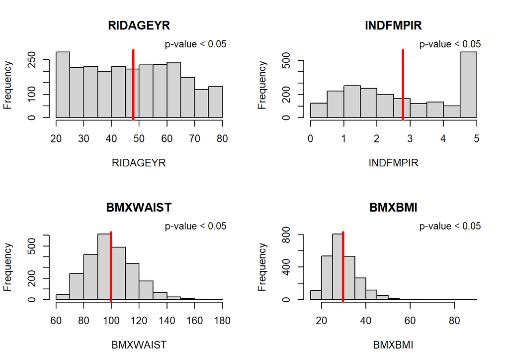

```
## [1] "coluna:  5 LUXSMED"
##
##  Anderson-Darling normality test
##
## data:  col_data
## A = 282.79, p-value < 2.2e-16
```

```
## [1] "coluna:  6 SBP"
##
##  Anderson-Darling normality test
##
## data:  col_data
## A = 21.051, p-value < 2.2e-16
```

```
## [1] "coluna:  7 DBP"
##
##  Anderson-Darling normality test
##
## data:  col_data
## A = 5.4781, p-value = 1.651e-13
```

```
## [1] "coluna:  8 LUXCAPM"
##
##  Anderson-Darling normality test
##
## data:  col_data
## A = 3.0808, p-value = 9.947e-08
```

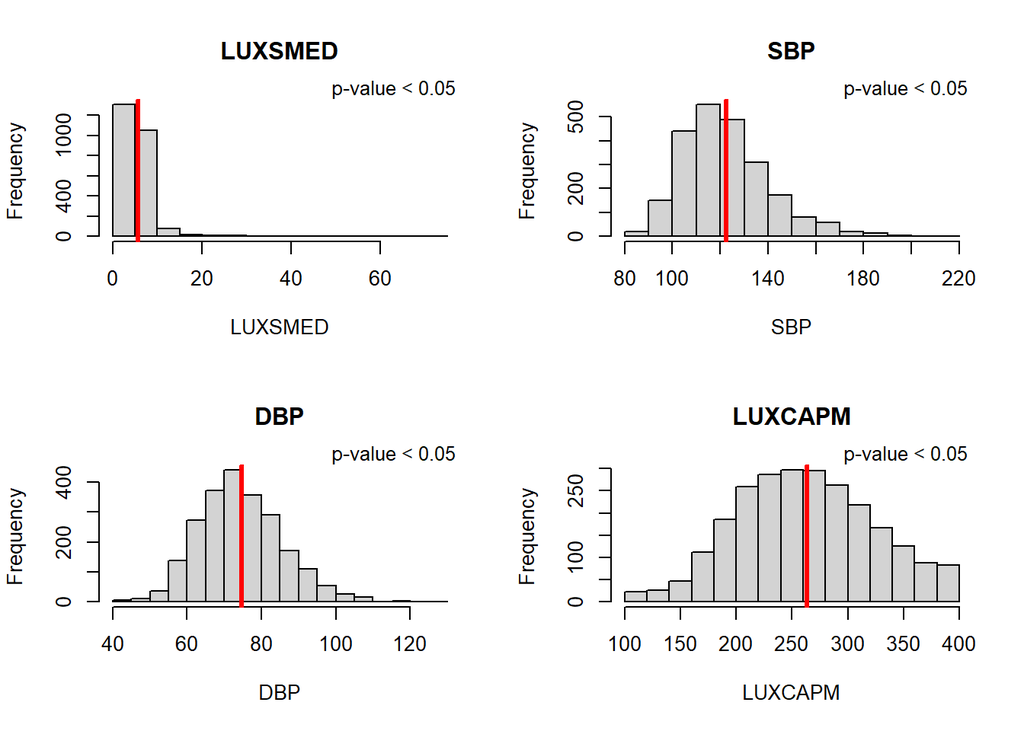

```
## [1] "coluna:  9 HSI"
##
##  Anderson-Darling normality test
##
## data:  col_data
## A = 19.848, p-value < 2.2e-16
```

```
## [1] "coluna:  10 FLI"
##
##  Anderson-Darling normality test
##
## data:  col_data
## A = 59.552, p-value < 2.2e-16
```

```
## [1] "coluna:  11 LBXTC"
##
##  Anderson-Darling normality test
##
## data:  col_data
## A = 9.3716, p-value < 2.2e-16
```

```
## [1] "coluna:  12 LBDHDD"
##
##  Anderson-Darling normality test
##
## data:  col_data
## A = 32.907, p-value < 2.2e-16
```

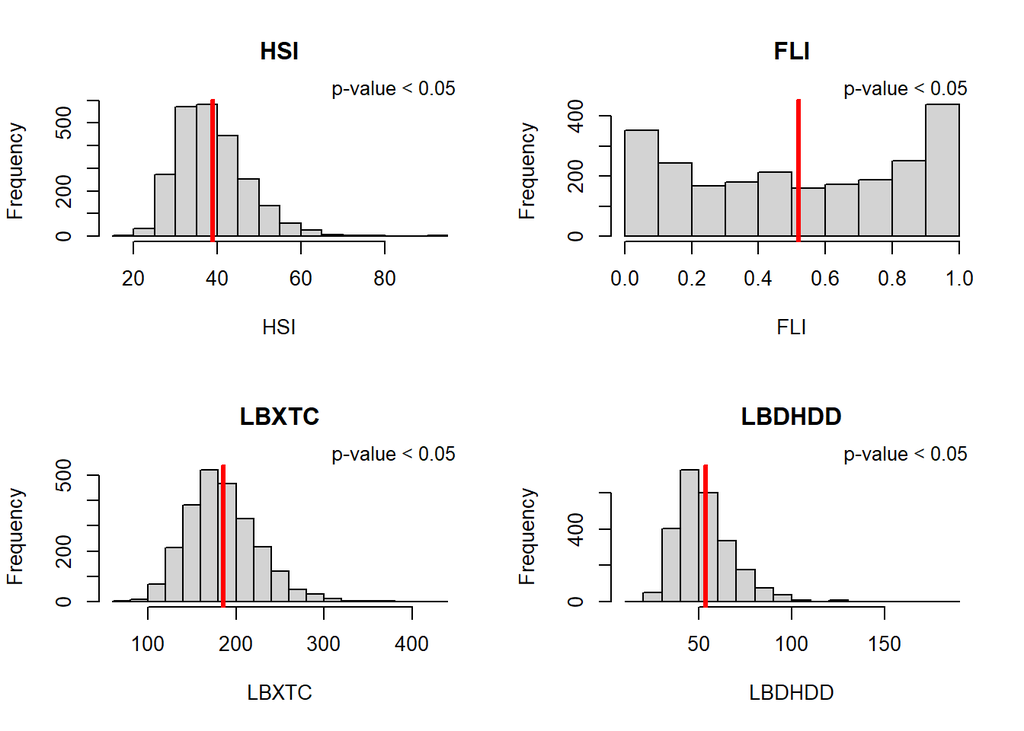

```
## [1] "coluna:  13 LBXGLU"
##
##  Anderson-Darling normality test
##
## data:  col_data
## A = 301.02, p-value < 2.2e-16
```

```
## [1] "coluna:  14 LBXIN"
##
##  Anderson-Darling normality test
##
## data:  col_data
## A = 352.71, p-value < 2.2e-16
```

```
## [1] "coluna:  15 LBXGH"
##
##  Anderson-Darling normality test
##
## data:  col_data
## A = 229.43, p-value < 2.2e-16
```

```
## [1] "coluna:  16 LBDLDL"
##
##  Anderson-Darling normality test
##
## data:  col_data
## A = 9.0923, p-value < 2.2e-16
```

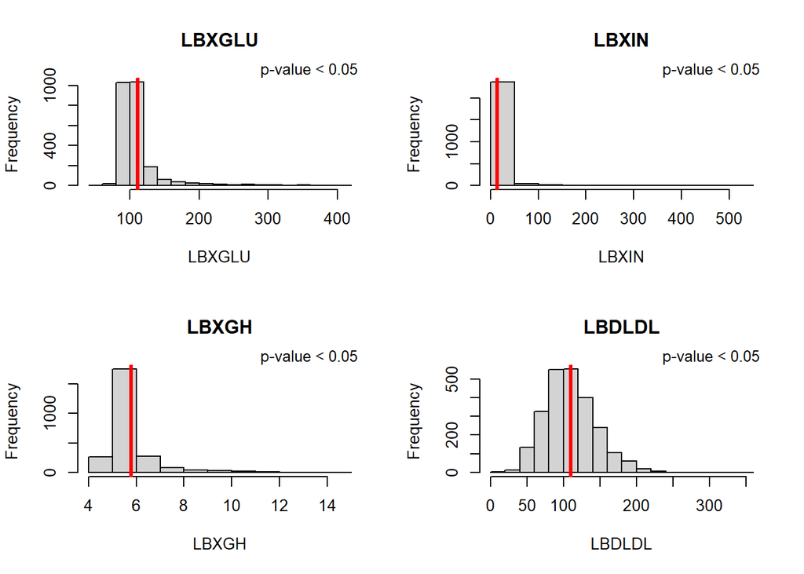

```
## [1] "coluna:  17 LBXTR"
##
##  Anderson-Darling normality test
##
## data:  col_data
## A = 177.14, p-value < 2.2e-16
```

```
## [1] "coluna:  18 LBXSATSI"
##
##  Anderson-Darling normality test
##
## data:  col_data
## A = 158.62, p-value < 2.2e-16
```

```
## [1] "coluna:  19 LBXSASSI"
##
##  Anderson-Darling normality test
##
## data:  col_data
## A = 177.35, p-value < 2.2e-16
```

```
## [1] "coluna:  20 LBXSGTSI"
##
##  Anderson-Darling normality test
##
## data:  col_data
## A = 297.3, p-value < 2.2e-16
```

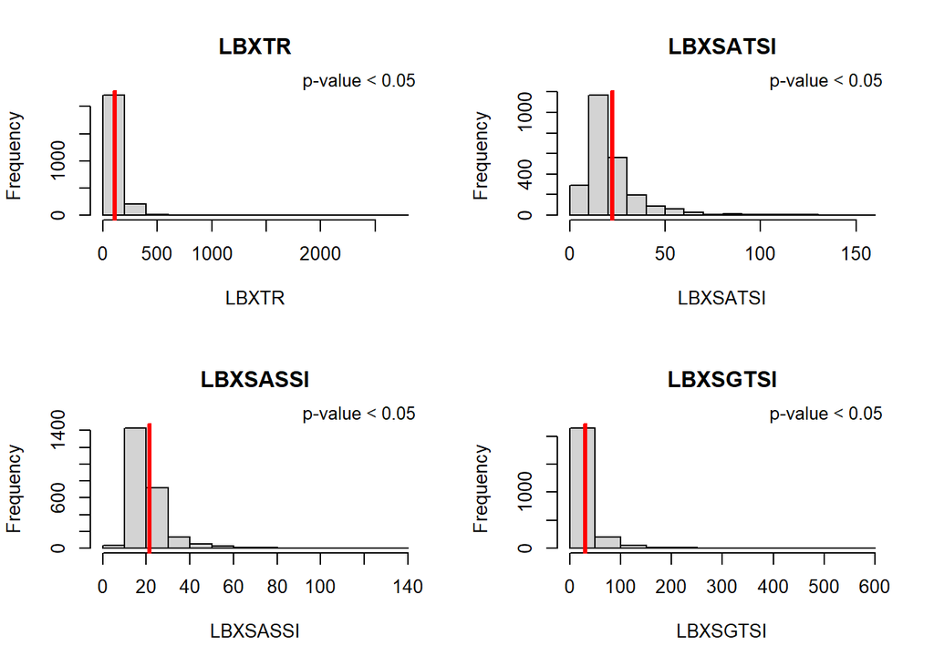

```
## [1] "coluna:  21 HOMAIR"
##
##  Anderson-Darling normality test
##
## data:  col_data
## A = 415.91, p-value < 2.2e-16
```

```
## [1] "coluna:  22 PAD680"
##
##  Anderson-Darling normality test
##
## data:  col_data
## A = 44.865, p-value < 2.2e-16
```

```
## [1] "coluna:  23 WORK_ACTIVITY"
##
##  Anderson-Darling normality test
##
## data:  col_data
## A = 343.14, p-value < 2.2e-16
```

```
## [1] "coluna:  24 TRANSPORTATION_ACTIVITY"
##
##  Anderson-Darling normality test
##
## data:  col_data
## A = 626.78, p-value < 2.2e-16
```

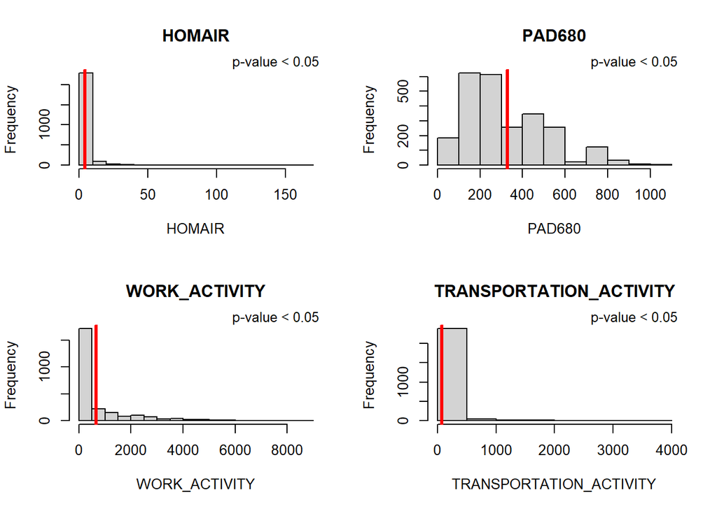

```
## [1] "coluna:  25 RECREATIONAL_ACTIVITY"
##
##  Anderson-Darling normality test
##
## data:  col_data
## A = 265.66, p-value < 2.2e-16
```

```
## [1] "coluna:  26 MVPA"
##
##  Anderson-Darling normality test
##
## data:  col_data
## A = 271.22, p-value < 2.2e-16
```

```
## [1] "coluna:  27 PA_MET"
##
##  Anderson-Darling normality test
##
## data:  col_data
## A = 271.22, p-value < 2.2e-16
```

```
## [1] "coluna:  28 AST_ALT"
##
##  Anderson-Darling normality test
##
## data:  col_data
## A = 35.069, p-value < 2.2e-16
```

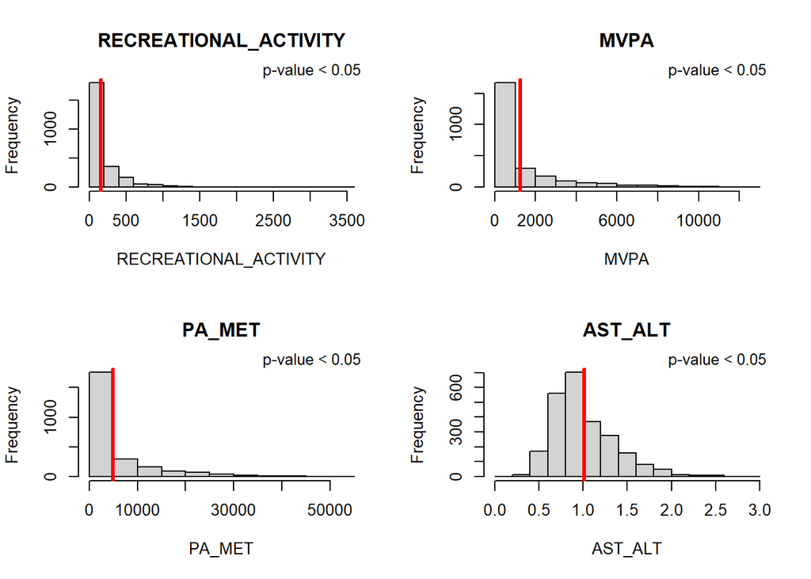

```
## [1] "coluna:  29 KCAL_MEAN"
##
##  Anderson-Darling normality test
##
## data:  col_data
## A = 21.559, p-value < 2.2e-16
```

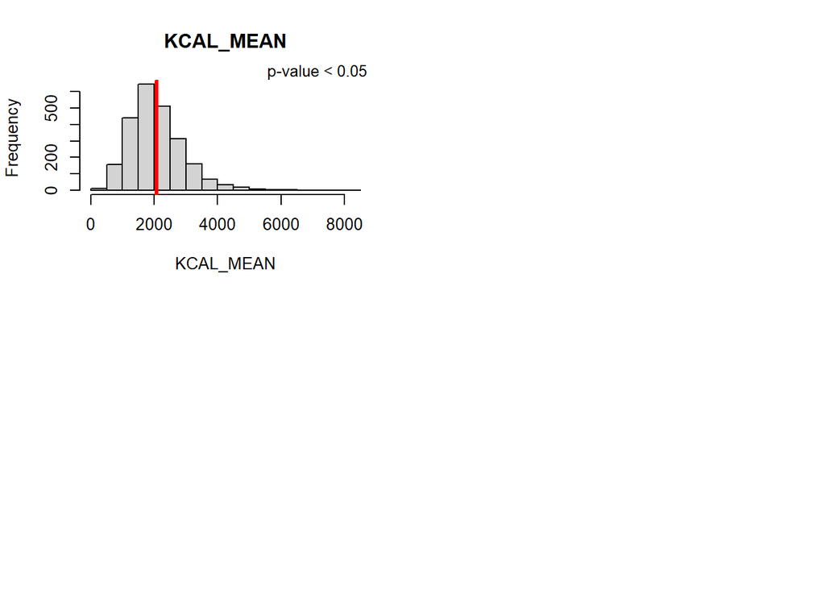

```r
# Ckecking Data Distribution

df_aux <- svy_design_subset$variables %>%
  select(where(is.numeric), -SEQN, -WTSAFPRP, -SDMVPSU, -SDMVSTRA)

par(mfrow = c(2, 2))

normalidade <- c()
for (a in 1:length(df_aux)) {
  col_data <- df_aux[[a]] # Seleciona a coluna atual
  MEAN <- mean(col_data, na.rm = TRUE)  # Calcula a média da coluna, removendo NAs
  normalidade[[a]] <- nortest::ad.test(col_data)
  col_name <- colnames(df_aux)[a]
  print(paste("coluna: ", a, col_name))
  print(ad.test(col_data))
  hist(col_data, main = col_name, xlab = col_name)
  abline(v = MEAN, lwd = 3, col = "red") # Adiciona a linha média
  mtext(ifelse(normalidade[[a]]$p.value < 0.05, paste("p-value < 0.05 "), paste("p-value > 0.05 ")), side = 3, adj = 1, cex = 0.8)
}
```

```r
descriptive_vars <- c("SB_CATEGORIC", "RIDAGEYR", "RIAGENDR", "RIDRETH1", "DMDEDUC2", "INDFMPIR", "BMXBMI", "BMXWAIST", "OVERWEIGHT_OBESE", "SBP", "DBP", "HTN", "LBXTC", "LBDLDL", "LBDHDD", "LBXTR", "LOW_HDL", "HYPERTRIGLY", "LBXGLU", "LBXIN", "LBXGH", "HOMAIR", "DYSGLYCAEMIA_DM2", "LBXSGTSI", "LBXSATSI", "LBXSASSI", "AST_ALT", "KCAL_MEAN", "SMOKING", "ALCOHOL_USE", "PAD680", "LUXCAPM", "LUXSMED", "MASLD", "HEPATIC_FIBROUSIS", "NAFLD", "HSI", "FLI", "MVPA", "WORK_ACTIVITY", "TRANSPORTATION_ACTIVITY", "RECREATIONAL_ACTIVITY")

# Criar um vetor nomeado com os rótulos personalizados
custom_labels <- list(
  PAD680 = "Sedentary Behavior (h)",
  SB_CATEGORIC = "Sedentary Behavior Quintile",
  MASLD = "MASLD (CAP ≥ 248 db/m)",
  HEPATIC_FIBROUSIS = "Hepatic Advanced Fibrosis (LSM ≥ 8 kPa)",
  NAFLD = "NAFLD (CAP ≥ 248 db/m)",
  SEQN = "ID",
  RIAGENDR = "Sex (M/F)",
  RIDAGEYR = "Age (yr)",
  RIDRETH1 = "Race",
  DMDEDUC2 = "Education",
  INDFMPIR = "Poverty Income Ratio",
  BMXBMI = "BMI (Kg/m²)",
  BMXWAIST = "Waist Circumference (cm)",
  OVERWEIGHT_OBESE = "Overweight/Obesity",
  LUXSMED = "Liver Stifness (Kpa)",
  LUXCAPM = "Median CAP (dB/m)",
  HSI = "HSI",
  FLI = "FLI",
  LBXTC = "Total Cholesterol (mg/dL)",
  LBDLDL = "LDL-Cholesterol (mg/dL)",
  LBDHDD = "HDL-Cholesterol (mg/dL)",
  LBXTR = "Fasting Triglycerides (mg/dL)",
  LOW_HDL = "Low-HDL",
  HYPERTRIGLY = "Hypertriglyceridemia",
  LBXGLU = "Fasting Glucose (mg/dL)",
  LBXIN = "Insulin (µU/mL)",
  LBXGH = "HbA1C (%)",
  HOMAIR = "HOMA-IR",
  DIABETES = "Diabetes",
  DYSGLYCAEMIA_DM2 = "Dysglycaemia or DM2",
  SBP = "SBP (mmHg)",
  DBP = "DBP (mmHg)",
  HTN = "Hypertension",
  LBXSATSI = "ALT (U/L)",
  LBXSASSI = "AST (U/L)",
  AST_ALT = "ALT/AST",
  LBXSGTSI = "GGT (U/L)",
  KCAL_MEAN = "Total Energy Intake (kcal/d)",
  SMOKING = "Smoking Habit",
  ALCOHOL_USE = "Alcohol Intake",
  MVPA = "MVPA",
  PA_MET = "MET (hours/week)",
  WORK_ACTIVITY = "Work-Related Activity",
  TRANSPORTATION_ACTIVITY = "Walking or Bicycling for Transportation",
  RECREATIONAL_ACTIVITY = "Leisure-Time Physical Activity"
)


# Gerar tabela descritiva
descriptive_tbl <- svy_design_subset %>%
  tbl_svysummary(
    by = SB_CATEGORIC, # Estratificação pelos quintis de comportamento sedentário
    include = all_of(descriptive_vars),          # Variáveis a incluir
    missing = "no",                      # Excluir valores ausentes
    statistic = list(
      all_continuous() ~ "{mean} ± {sd}",           # Média ± desvio padrão para variáveis contínuas
      all_categorical() ~ "{n} ({p}%)",
      type = list(RIAGENDR ~ "dichotomous")
    ),
    label = custom_labels
  ) %>%
  modify_header(
    label ~ "**Variables**",                       # Cabeçalho para as variáveis
    stat_1 = "**1st Quintile** <br>N = {n}",
    stat_2 = "**2nd Quintile** <br>N = {n}",
    stat_3 = "**3rd Quintile** <br>N = {n}",
    stat_4 = "**4th Quintile** <br>N = {n}",
    stat_5 = "**5th Quintile** <br>N = {n}"
  ) %>%
  modify_caption("**Table 1. Characteristics of the Total Sample and Stratified by Sedentary Behavior Quintiles**") %>%
  modify_spanning_header(
    c("stat_1", "stat_2", "stat_3", "stat_4", "stat_5") ~ "**Sedentary Behaviour Quintiles**"
  ) %>%
  bold_labels() %>%
  add_overall(
    last = FALSE,
    col_label = "**All Participants**<br>N = {N}"
  )

descriptive_tbl
```

**Table 1. Characteristics of the Total Sample and Stratified by Sedentary Behavior Quintiles**

| **Variables** | **All Participants** N = 171711851.64708<sup>1</sup> | **Sedentary Behaviour Quintiles** **1st Quintile** N = 29958395.1796981<sup>1</sup> | **Sedentary Behaviour Quintiles** **2nd Quintile** N = 33670734.6019899<sup>1</sup> | **Sedentary Behaviour Quintiles** **3rd Quintile** N = 32151605.6564404<sup>1</sup> | **Sedentary Behaviour Quintiles** **4th Quintile** N = 33461674.97519<sup>1</sup> | **Sedentary Behaviour Quintiles** **5th Quintile** N = 42469441.2337619<sup>1</sup> |
| --- | --- | --- | --- | --- | --- | --- |
| Age (yr) | 46 ± 17 | 43 ± 16 | 47 ± 16 | 47 ± 18 | 47 ± 17 | 45 ± 16 |
| Sex (M/F) |  |  |  |  |  |  |
| 1 | 87,415,471 (51%) | 15,630,783 (52%) | 17,088,013 (51%) | 14,829,748 (46%) | 17,348,174 (52%) | 22,518,753 (53%) |
| 2 | 84,296,381 (49%) | 14,327,612 (48%) | 16,582,722 (49%) | 17,321,858 (54%) | 16,113,501 (48%) | 19,950,688 (47%) |
| Race |  |  |  |  |  |  |
| 1 | 28,052,894 (16%) | 9,465,830 (32%) | 5,874,925 (17%) | 4,676,042 (15%) | 4,344,584 (13%) | 3,691,514 (8.7%) |
| 3 | 107,984,325 (63%) | 14,000,697 (47%) | 21,266,629 (63%) | 19,746,147 (61%) | 22,419,543 (67%) | 30,551,310 (72%) |
| 4 | 19,041,063 (11%) | 3,606,894 (12%) | 3,821,580 (11%) | 4,271,914 (13%) | 3,142,626 (9.4%) | 4,198,049 (9.9%) |
| 5 | 16,633,570 (9.7%) | 2,884,975 (9.6%) | 2,707,601 (8.0%) | 3,457,503 (11%) | 3,554,922 (11%) | 4,028,569 (9.5%) |
| Education |  |  |  |  |  |  |
| 1 | 15,793,210 (9.2%) | 5,694,517 (19%) | 3,127,551 (9.3%) | 2,418,206 (7.5%) | 2,325,274 (6.9%) | 2,227,662 (5.2%) |
| 2 | 42,909,327 (25%) | 10,319,766 (34%) | 9,514,406 (28%) | 9,701,677 (30%) | 6,406,148 (19%) | 6,967,331 (16%) |
| 3 | 52,614,771 (31%) | 8,550,189 (29%) | 10,832,151 (32%) | 9,055,739 (28%) | 10,762,158 (32%) | 13,414,533 (32%) |
| 4 | 60,380,152 (35%) | 5,393,923 (18%) | 10,196,626 (30%) | 10,975,984 (34%) | 13,968,096 (42%) | 19,845,524 (47%) |
| Poverty Income Ratio | 3.31 ± 1.60 | 2.60 ± 1.61 | 3.20 ± 1.57 | 3.15 ± 1.62 | 3.58 ± 1.49 | 3.77 ± 1.48 |
| BMI (Kg/m²) | 29 ± 7 | 28 ± 6 | 29 ± 7 | 30 ± 8 | 29 ± 7 | 30 ± 7 |
| Waist Circumference (cm) | 99 ± 16 | 96 ± 15 | 99 ± 16 | 100 ± 18 | 100 ± 15 | 101 ± 17 |
| Overweight/Obesity |  |  |  |  |  |  |
| 0 | 45,124,061 (26%) | 9,729,369 (33%) | 7,778,540 (23%) | 9,059,969 (28%) | 8,409,383 (25%) | 10,146,800 (24%) |
| 1 | 125,942,783 (74%) | 20,045,684 (67%) | 25,743,007 (77%) | 23,015,467 (72%) | 24,967,471 (75%) | 32,171,154 (76%) |
| SBP (mmHg) | 120 ± 16 | 119 ± 16 | 121 ± 16 | 120 ± 16 | 121 ± 16 | 119 ± 15 |
| DBP (mmHg) | 74 ± 11 | 73 ± 11 | 74 ± 11 | 74 ± 11 | 75 ± 10 | 74 ± 10 |
| Hypertension |  |  |  |  |  |  |
| 0 | 100,275,906 (58%) | 18,651,392 (62%) | 19,541,235 (58%) | 18,705,947 (58%) | 19,770,404 (59%) | 23,606,929 (56%) |
| 1 | 71,435,945 (42%) | 11,307,004 (38%) | 14,129,500 (42%) | 13,445,659 (42%) | 13,691,271 (41%) | 18,862,512 (44%) |
| Total Cholesterol (mg/dL) | 186 ± 40 | 183 ± 38 | 192 ± 43 | 186 ± 41 | 185 ± 42 | 184 ± 39 |
| LDL-Cholesterol (mg/dL) | 110 ± 35 | 108 ± 33 | 114 ± 35 | 111 ± 36 | 110 ± 35 | 109 ± 34 |
| HDL-Cholesterol (mg/dL) | 54 ± 16 | 55 ± 18 | 56 ± 16 | 54 ± 17 | 53 ± 16 | 53 ± 14 |
| Fasting Triglycerides (mg/dL) | 110 ± 95 | 107 ± 101 | 112 ± 74 | 108 ± 70 | 114 ± 140 | 111 ± 76 |
| Low-HDL |  |  |  |  |  |  |
| 0 | 124,174,300 (73%) | 21,665,620 (73%) | 25,334,148 (76%) | 22,188,464 (70%) | 22,724,036 (70%) | 32,262,031 (77%) |
| 1 | 45,407,558 (27%) | 7,963,962 (27%) | 8,097,475 (24%) | 9,705,718 (30%) | 9,757,437 (30%) | 9,882,966 (23%) |
| Hypertriglyceridemia |  |  |  |  |  |  |
| 0 | 114,348,764 (67%) | 21,956,064 (74%) | 22,771,728 (68%) | 20,026,585 (63%) | 21,483,954 (66%) | 28,110,434 (67%) |
| 1 | 55,465,026 (33%) | 7,801,275 (26%) | 10,659,896 (32%) | 11,867,597 (37%) | 11,053,113 (34%) | 14,083,145 (33%) |
| Fasting Glucose (mg/dL) | 108 ± 30 | 108 ± 32 | 111 ± 41 | 108 ± 24 | 105 ± 20 | 108 ± 29 |
| Insulin (µU/mL) | 13 ± 22 | 12 ± 11 | 12 ± 12 | 13 ± 12 | 15 ± 36 | 15 ± 26 |
| HbA1C (%) | 5.61 ± 0.88 | 5.64 ± 0.87 | 5.70 ± 1.03 | 5.59 ± 0.77 | 5.51 ± 0.69 | 5.60 ± 0.98 |
| HOMA-IR | 3.82 ± 8.33 | 3.23 ± 3.55 | 3.45 ± 4.82 | 3.65 ± 4.07 | 4.06 ± 10.02 | 4.49 ± 12.69 |
| Dysglycaemia or DM2 |  |  |  |  |  |  |
| 0 | 59,970,981 (35%) | 10,881,706 (36%) | 10,988,867 (33%) | 11,112,780 (35%) | 12,291,737 (37%) | 14,695,893 (35%) |
| 1 | 111,740,870 (65%) | 19,076,690 (64%) | 22,681,868 (67%) | 21,038,826 (65%) | 21,169,938 (63%) | 27,773,549 (65%) |
| GGT (U/L) | 28 ± 29 | 28 ± 30 | 26 ± 25 | 29 ± 29 | 29 ± 28 | 29 ± 34 |
| ALT (U/L) | 22 ± 15 | 21 ± 15 | 22 ± 15 | 23 ± 15 | 22 ± 11 | 24 ± 17 |
| AST (U/L) | 21 ± 10 | 21 ± 10 | 22 ± 10 | 21 ± 10 | 21 ± 8 | 22 ± 11 |
| ALT/AST | 1.02 ± 0.35 | 1.00 ± 0.35 | 1.01 ± 0.33 | 1.04 ± 0.39 | 1.02 ± 0.31 | 1.04 ± 0.38 |
| Total Energy Intake (kcal/d) | 2,115 ± 799 | 2,078 ± 878 | 2,121 ± 812 | 2,078 ± 846 | 2,154 ± 776 | 2,132 ± 705 |
| Smoking Habit |  |  |  |  |  |  |
| 0 | 100,647,680 (59%) | 17,546,251 (59%) | 17,618,416 (52%) | 18,910,562 (59%) | 19,575,442 (59%) | 26,997,010 (64%) |
| 1 | 44,469,963 (26%) | 6,208,156 (21%) | 10,113,679 (30%) | 7,516,717 (23%) | 10,140,295 (30%) | 10,491,116 (25%) |
| 2 | 26,557,204 (15%) | 6,203,988 (21%) | 5,938,640 (18%) | 5,724,326 (18%) | 3,708,934 (11%) | 4,981,315 (12%) |
| Alcohol Intake |  |  |  |  |  |  |
| 0 | 13,475,724 (7.8%) | 2,956,561 (9.9%) | 3,127,950 (9.3%) | 2,394,443 (7.4%) | 2,509,964 (7.5%) | 2,486,806 (5.9%) |
| 1 | 24,068,933 (14%) | 3,951,795 (13%) | 4,801,029 (14%) | 4,840,003 (15%) | 5,552,672 (17%) | 4,923,434 (12%) |
| 2 | 134,167,195 (78%) | 23,050,039 (77%) | 25,741,756 (76%) | 24,917,160 (77%) | 25,399,039 (76%) | 35,059,202 (83%) |
| Sedentary Behavior (h) | 354 ± 204 | 106 ± 40 | 204 ± 29 | 294 ± 41 | 422 ± 54 | 640 ± 114 |
| Median CAP (dB/m) | 261 ± 61 | 250 ± 59 | 263 ± 62 | 261 ± 63 | 260 ± 60 | 269 ± 61 |
| Liver Stifness (Kpa) | 5.47 ± 3.13 | 5.35 ± 3.29 | 5.75 ± 4.00 | 5.57 ± 2.21 | 5.29 ± 3.54 | 5.38 ± 2.41 |
| MASLD (CAP ≥ 248 db/m) |  |  |  |  |  |  |
| 0 | 79,667,134 (46%) | 16,202,254 (54%) | 14,535,122 (43%) | 15,310,807 (48%) | 15,624,305 (47%) | 17,994,645 (42%) |
| 1 | 92,044,718 (54%) | 13,756,141 (46%) | 19,135,612 (57%) | 16,840,798 (52%) | 17,837,370 (53%) | 24,474,796 (58%) |
| Hepatic Advanced Fibrosis (LSM ≥ 8 kPa) |  |  |  |  |  |  |
| 0 | 158,092,753 (92%) | 28,007,872 (93%) | 30,710,977 (91%) | 29,060,813 (90%) | 31,718,014 (95%) | 38,595,075 (91%) |
| 1 | 13,619,099 (7.9%) | 1,950,523 (6.5%) | 2,959,757 (8.8%) | 3,090,792 (9.6%) | 1,743,661 (5.2%) | 3,874,366 (9.1%) |
| NAFLD (CAP ≥ 248 db/m) |  |  |  |  |  |  |
| 0 | 74,370,555 (43%) | 15,157,393 (51%) | 13,564,111 (40%) | 13,889,200 (43%) | 14,989,762 (45%) | 16,770,089 (39%) |
| 1 | 97,341,297 (57%) | 14,801,002 (49%) | 20,106,623 (60%) | 18,262,406 (57%) | 18,471,913 (55%) | 25,699,352 (61%) |
| HSI | 38 ± 8 | 37 ± 8 | 38 ± 8 | 39 ± 9 | 39 ± 8 | 39 ± 9 |
| FLI | 0.50 ± 0.33 | 0.45 ± 0.32 | 0.49 ± 0.32 | 0.51 ± 0.35 | 0.51 ± 0.32 | 0.53 ± 0.34 |
| MVPA | 1,232 ± 1,810 | 2,114 ± 2,481 | 1,653 ± 1,946 | 1,139 ± 1,743 | 940 ± 1,445 | 576 ± 884 |
| Work-Related Activity | 668 ± 1,143 | 1,201 ± 1,535 | 978 ± 1,282 | 610 ± 1,034 | 480 ± 927 | 236 ± 582 |
| Walking or Bicycling for Transportation | 59 ± 239 | 87 ± 318 | 74 ± 240 | 73 ± 339 | 41 ± 132 | 29 ± 110 |
| Leisure-Time Physical Activity | 176 ± 263 | 188 ± 300 | 179 ± 259 | 174 ± 263 | 178 ± 271 | 165 ± 230 |

<sup>1</sup> Mean ± SD; n (%)

```r
# Exportar para CSV e DOCX/PDF
export(
  as_tibble(descriptive_tbl),
  here("Tables", "descriptive_table.csv")
)

gtsave(as_gt(descriptive_tbl), here("Tables", "descriptive_table.docx"))
gtsave(as_gt(descriptive_tbl), here("Tables", "descriptive_table.pdf"))
```

```
## file:///C:/Users/USURIO~2/AppData/Local/Temp/RtmpGgFUfI/file4ab07bf2336.html screenshot completed
```

*Note*: If a variable is a factor with exactly two levels labeled “Yes” and “No”, then tbl_summary() by default will only include the row corresponding to “Yes”. The same applies with variables that have values TRUE/FALSE or 1/0. Use the value option to change the row displayed (see ?gtsummary::tbl_summary for details). Alternatively, set type to “categorical” to display both rows.

A adição de p-valores na Tabela 1 não é recomendada. A função principal da Tabela 1 é descrever as características da amostra e não testar diferenças estatísticas entre os grupos. O uso de p-valores nesta etapa pode ser enganoso, pois:

P-valores são altamente dependentes do tamanho amostral: pequenas diferenças podem ser estatisticamente significativas em grandes amostras (sem relevância clínica), enquanto diferenças importantes podem não ser detectadas em amostras pequenas.

Confundimento não deve ser avaliado com base em p-valores, mas sim com base em conhecimento prévio e em análises ajustadas.

Em estudos randomizados, diferenças entre grupos são atribuídas ao acaso, tornando os p-valores ainda mais irrelevantes.

Conclusão: a Tabela 1 deve focar na apresentação das magnitudes e distribuições das variáveis, sem inferência estatística.

(Fontes: Vandenbroucke et al., 2007; Moher et al., 2010, https://bookdown.org/rwnahhas/RMPH/datasumm-table1.html)

# Modelos de regressão

```r
# Utilizando para a regressão apenas casos em que todas as variaveis da regressão estão completas

explanatory_vars <- setdiff(
  descriptive_vars,
  c(
    "LUXCAPM",
    "LUXSMED",
    "MASLD",
    "HEPATIC_FIBROUSIS",
    "NAFLD",
    "HSI",
    "FLI"
  )
)

print(explanatory_vars)
```

```
##  [1] "SB_CATEGORIC"            "RIDAGEYR"
##  [3] "RIAGENDR"                "RIDRETH1"
##  [5] "DMDEDUC2"                "INDFMPIR"
##  [7] "BMXBMI"                  "BMXWAIST"
##  [9] "OVERWEIGHT_OBESE"        "SBP"
## [11] "DBP"                     "HTN"
## [13] "LBXTC"                   "LBDLDL"
## [15] "LBDHDD"                  "LBXTR"
## [17] "LOW_HDL"                 "HYPERTRIGLY"
## [19] "LBXGLU"                  "LBXIN"
## [21] "LBXGH"                   "HOMAIR"
## [23] "DYSGLYCAEMIA_DM2"        "LBXSGTSI"
## [25] "LBXSATSI"                "LBXSASSI"
## [27] "AST_ALT"                 "KCAL_MEAN"
## [29] "SMOKING"                 "ALCOHOL_USE"
## [31] "PAD680"                  "MVPA"
## [33] "WORK_ACTIVITY"           "TRANSPORTATION_ACTIVITY"
## [35] "RECREATIONAL_ACTIVITY"
```

```r
univ_tab <- svy_design_subset$variables %>%
  dplyr::select(all_of(explanatory_vars), MASLD) %>% ## selecione as variáveis de interesse

  tbl_uvregression(                         ## produz uma tabela univariável
    method = glm,                           ## define qual regressão será rodada (glm)
    y = MASLD,                              ## define a variável da evolução clínica (outcome)
    method.args = list(family = binomial),  ## define qual tipo de glm será rodador (logístico)
    exponentiate = TRUE,                     ## realiza a exponenciação para produzir as probabilidades (em vez de probabilidaes em log)
    label = custom_labels
  )
```

[output not shown]

```r
print(univ_tab)
```

[output not shown]

[output cut: 744 more lines]

[output not shown]

```r
export(
  as_tibble(descriptive_tbl),
  here("Tables", "univariate_table.csv")
)

gtsave(as_gt(descriptive_tbl), here("Tables", "univariate_table.docx"))
gtsave(as_gt(descriptive_tbl), here("Tables", "univariate_table.pdf"))
```

```
## file:///C:/Users/USURIO~2/AppData/Local/Temp/RtmpGgFUfI/file4ab01f9821cc.html screenshot completed
```

```r
### Correlation between explonatory vars and Median CAP

# Função para plotar e salvar os gráficos
plot_and_save <- function(data, y_var, x_vars, output_dir = here("Figures", "Univariate_correlations")) {
  # Criar diretório de saída, se não existir
  if (!dir.exists(output_dir)) {
    dir.create(output_dir)
  }

  for (x_var in x_vars) {
    x <- data[[x_var]]
    y <- data[[y_var]]

    # Nome do arquivo de saída
    file_name <- paste0(output_dir, "/", y_var, "_vs_", x_var, ".png")

    # Ignorar variáveis completamente vazias
    if (all(is.na(x)) | all(is.na(y))) {
      message(paste("Variável ignorada (só contém NAs):", x_var))
      next
    }

    # Salvar o gráfico em um arquivo
    png(file_name, width = 800, height = 600) # Ajuste o tamanho conforme necessário
    if (is.numeric(x)) {
      # Se variável for numérica
      tryCatch({
        plot(
          x, y,
          col = "gray",
          xlab = x_var,
          ylab = y_var,
          las = 1,
          pch = 20,
          font.lab = 2,
          font.axis = 2,
          main = paste(y_var, "vs", x_var)
        )
        abline(lm(y ~ x), lwd = 2, col = "red")
      }, error = function(e) {
        message(paste("Erro ao plotar variável contínua:", x_var, "-", e$message))
      })

    } else {
      # Se variável for categórica
      tryCatch({
        plot(
          as.factor(x), y,
          col = "gray",
          ylab = y_var,
          xlab = x_var,
          las = 1,
          pch = 20,
          font.lab = 2,
          font.axis = 2,
          main = paste(y_var, "vs", x_var)
        )

        MEANS <- tapply(y, x, mean, na.rm = TRUE)
        points(levels(as.factor(x)), MEANS, pch = 20, cex = 3, col = "blue")
      }, error = function(e) {
        message(paste("Erro ao plotar variável categórica:", x_var, "-", e$message))
      })
    }
    dev.off() # Fechar o dispositivo gráfico
  }
}

# Diretório de saída para os gráficos
output_directory <- here("Figures", "Univariate_correlations")

# Chamar a função para plotar e salvar os gráficos
plot_and_save(svy_design_subset$variables, y_var = "LUXCAPM", x_vars = explanatory_vars, output_dir = output_directory)
```

#LIXO IREI GUARDAR PARA O FUTURO

# Alcohol use

[output not shown]

df_temp$RIDRETH1 <- recode_factor( as.factor(df_temp$RIDRETH1), `1` = “Hispanic”, `2` = “Hispanic”, `3` = “Non-Hispanic White”, `4` = “Non-Hispanic Black”, `5` = “Other Race” )

df_temp$RIDRETH3 <- recode_factor( as.factor(df_temp$RIDRETH1), `1` = “Hispanic”, `2` = “Hispanic”, `3` = “Non-Hispanic White”, `4` = “Non-Hispanic Black”, `6` = “Non-Hispanic Asian”, `7` = “Other Race” )

df_temp$DMDEDUC2 <- recode_factor(df_temp$DMDEDUC2, `1` = “Less than a high school education”, `2` = “Less than a high school education”, `3` = “high school graduate, GED, or equivalent”, `4` = “Some College or AA degree”, `5` = “College Graduate or above”, `7` = NA_character_, `9` = NA_character_ )

descriptive_var <- c(“Sedentary Behavior Quintile”, “Age (yr)”, “Sex (M/F)”, “Race”, “Education”, “Poverty Income Ratio”, “BMI (Kg/m2)”, “Waist Circumference (cm)”, “Overweight/Obesity”, “SBP (mmHg)”, “DBP (mmHg)”, “Hypertension”, “Total Cholesterol (mg/dL)”, “LDL-Cholesterol (mg/dL)”, “HDL-Cholesterol (mg/dL)”, “Fasting Triglycerides (mg/dL)”, “Low-HDL”, “Hypertriglyceridemia”, “Fasting Glucose (mg/dL)”, “Insulin (µU/mL)”, “HbA1C (%)”, “HOMA-IR”, “Dysglycaemia or DM2”, “GGT (U/L)”, “ALT (U/L)”, “AST (U/L)”, “ALT/AST”, “Total Energy Intake (kcal/d)”, “Smoking Habit”, “Alcohol Intake”, “Sedentary Behavior (h)”, “Median CAP (dB/m)”, “Liver Stifness (Kpa)”, “MASLD (CAP ≥ 248 db/m)”, “Hepatic Advanced Fibrosis (LSM ≥ 8 kPa)”, “NAFLD (CAP ≥ 248 db/m)”, “HSI”, “FLI”, “MVPA”, “Work-Related Activity”, “Walking or Bicycling for Transportation”, “Leisure-Time Physical Activity”)

*Note* Exemplo de escrita dos resultados: Example 4.1 (continued): Linear regression was used to test the association between fasting glucose (mmol/L) and waist circumference (cm) using data from 965 adults from NHANES 2017-2018. 8.71% of the variation in fasting glucose was explained by waist circumference (R2 = .0871). There was a significant positive association between fasting glucose and waist circumference (B = 0.0278; 95% CI = 0.0221, 0.0334; p <.001). On average, for every 1-cm difference in waist circumference, adults differ in mean fasting glucose by 0.0278 mmol/L. Table 4.1 summarizes the regression results.